# Statistical Models for Data Science Assignment 1: U.S. population nutrition survey

# Assignment description

Assignment 1: U.S. population nutrition survey Report due at the beginning of class on December 8

The United States Department of Agriculture conducted a survey in 1995 and 1996, with a representative sample of U.S. households, to examine the relationships among dietary habits, knowledge and attitudes, and health. The data for the project, a subset of the full sample comprising 4036 observations, appear in four sheets of the Excel file called nutrition_data.xlsx. Descriptions of the variables appear in the file nutrition_vars.rtf,* and full information about the survey questions whose names start with “kq” is given in the file scale_vars.pdf.

Goal: To examine the variables affecting the BMI of the respondents.

## Load necessary libraries

```r
rm(list = ls())
library(readxl)
library(dplyr)
library(ggplot2)
library(tidyr)
library(tidyverse)
library(knitr)
```

## Task 1 - Merging Nutrition Survey Datasets

Combine the four sheets (main and scale, males and females) into a single R data frame. (Hints: You can save the sheets as four .csv files and read these in to R using read.csv(). Use merge() to combine the two sets of variables, and rbind() to combine males and females.)

```r
file_path_nutrition_data <- "Data/Nutrition_data.xlsx"

main_m_data <- read_excel(file_path_nutrition_data, sheet = "main_m")
scale_m_data <- read_excel(file_path_nutrition_data, sheet = "scale_m")
main_f_data <- read_excel(file_path_nutrition_data, sheet = "main_f")
scale_f_data <- read_excel(file_path_nutrition_data, sheet = "scale_f")

# combine 'main_m' and 'scale_m' data sets using merge()
main_scale_m_combined <- merge(main_m_data, scale_m_data, by = "hhid", all = TRUE)

# combine 'main_f' and 'scale_f' data sets using merge()
main_scale_f_combined <- merge(main_f_data, scale_f_data, by = "hhid", all = TRUE)

# combine the male and female data sets using rbind()
final_data <- rbind(main_scale_m_combined, main_scale_f_combined)

# view the structure of the final combined data frame
str(final_data)
```

```
## 'data.frame':    4036 obs. of  57 variables:
##  $ hhid      : num  10004 10005 10007 10010 10011 ...
##  $ region    : num  1 1 1 1 1 1 1 1 1 1 ...
##  $ urb       : num  2 2 2 2 2 2 2 2 2 2 ...
##  $ hhsize    : num  4 3 5 2 2 2 4 1 7 2 ...
##  $ income    : num  38000 14000 14613 55000 34000 ...
##  $ pctpov    : num  257 122 84 300 300 0 300 300 182 300 ...
##  $ povcat    : num  2 1 1 3 3 1 3 3 2 3 ...
##  $ fs_rcv12  : num  2 2 2 2 2 2 2 2 2 2 ...
##  $ age       : num  41 64 41 26 54 69 43 31 63 35 ...
##  $ sex.x     : num  1 1 1 1 1 1 1 1 1 1 ...
##  $ race      : num  1 1 1 1 1 1 3 1 5 1 ...
##  $ origin    : num  4 5 5 4 5 5 5 5 4 5 ...
##  $ head_hh   : num  1 1 1 1 1 1 1 1 1 1 ...
##  $ grade     : num  9 14 8 15 12 17 12 17 5 16 ...
```

[output cut: 43 more lines]

```r
# deal with the duplicate sex columns
drop_cols = c("sex.x", "sex.y")
final_data$sex = final_data$sex.x

# make sure the columns are identical before removing (this was caused because of merging data frames)
if(all(final_data$sex.x == final_data$sex.y)){
  final_data = final_data[,!(names(final_data) %in% drop_cols)]
}
# view the structure of the final combined data frame after removing the sex columns
str(final_data)
```

```
## 'data.frame':    4036 obs. of  56 variables:
##  $ hhid      : num  10004 10005 10007 10010 10011 ...
##  $ region    : num  1 1 1 1 1 1 1 1 1 1 ...
##  $ urb       : num  2 2 2 2 2 2 2 2 2 2 ...
##  $ hhsize    : num  4 3 5 2 2 2 4 1 7 2 ...
##  $ income    : num  38000 14000 14613 55000 34000 ...
##  $ pctpov    : num  257 122 84 300 300 0 300 300 182 300 ...
##  $ povcat    : num  2 1 1 3 3 1 3 3 2 3 ...
##  $ fs_rcv12  : num  2 2 2 2 2 2 2 2 2 2 ...
##  $ age       : num  41 64 41 26 54 69 43 31 63 35 ...
##  $ race      : num  1 1 1 1 1 1 3 1 5 1 ...
##  $ origin    : num  4 5 5 4 5 5 5 5 4 5 ...
##  $ head_hh   : num  1 1 1 1 1 1 1 1 1 1 ...
##  $ grade     : num  9 14 8 15 12 17 12 17 5 16 ...
##  $ emp_status: num  4 4 1 1 1 1 1 1 4 1 ...
```

[output cut: 42 more lines]

## Tasks 2 and 3 - Descriptive Analysis and Data Cleaning

2. Use descriptive methods (frequency tables, histograms, the pairs() function, etc.) to check the integrity and completeness of the following variables: region, urbanization, income, age, sex, race, education (highest grade completed), the five “diet” variables, exercise frequency, and self-reported weight status. Don’t forget to convert categorical variables to “factors”. (Note: In “real life,” questions about the data should generally be referred to the investigator to determine if there are errors in the data and, if so, whether these can be corrected.) Only the above predictor variables should be considered in the remaining questions.
3. For each variable, values that specify missing data (e.g., “indeterminate”, “not ascertained”) should be changed to NA.

```r
colnames(final_data)
```

```
##  [1] "hhid"       "region"     "urb"        "hhsize"     "income"
##  [6] "pctpov"     "povcat"     "fs_rcv12"   "age"        "race"
## [11] "origin"     "head_hh"    "grade"      "emp_status" "plan_yn"
## [16] "shop_yn"    "prep_yn"    "wic_yn"     "d1_tv"      "salt_typ"
## [21] "salt_frq"   "dt01"       "dt02"       "dt03"       "dt06"
## [26] "dt07"       "vt_freq"    "bmi_sp"     "health"     "doctor1"
## [31] "doctor2"    "doctor3"    "doctor4"    "doctor5"    "doctor6"
## [36] "doctor7"    "exercise"   "smk_100"    "smk_now"    "kq2_b"
## [41] "kq2_c"      "kq2_d"      "kq2_e"      "kq2_f"      "kq2_g"
## [46] "kq7"        "kq33_a"     "kq33_b"     "kq34"       "kq37"
## [51] "kq38"       "kq39"       "kq40"       "kq41"       "kq42"
## [56] "sex"
```

Variables with unclear names:  
“urb” = urbanization  
“grade” = highest grade completed  
“dt01”, “dt02”, “dt03”, “dt06”, “dt07” = the five “diet” variables  
“exercise” = exercise frequency  
“kq7” = self-reported weight status

Choose only variables of interest according to instructions

```r
vars_of_interest <- c("hhid", "region", "urb", "income", "age",
                      "sex", "race", "grade", "dt01", "dt02",
                      "dt03", "dt06", "dt07", "exercise", "kq7", "bmi_sp")

# select only the variables of interest from the final data frame
data_subset <- final_data %>% dplyr::select(all_of(vars_of_interest))

df_nutrition <- data_subset

# check the structure of the data
str(df_nutrition, vec.len=2)
```

```
## 'data.frame':    4036 obs. of  16 variables:
##  $ hhid    : num  10004 10005 ...
##  $ region  : num  1 1 1 1 1 ...
##  $ urb     : num  2 2 2 2 2 ...
##  $ income  : num  38000 14000 ...
##  $ age     : num  41 64 41 26 54 ...
##  $ sex     : num  1 1 1 1 1 ...
##  $ race    : num  1 1 1 1 1 ...
##  $ grade   : num  9 14 8 15 12 ...
##  $ dt01    : num  2 2 2 2 2 ...
##  $ dt02    : num  2 2 2 2 2 ...
##  $ dt03    : num  2 2 2 2 2 ...
##  $ dt06    : num  2 2 2 2 2 ...
##  $ dt07    : num  2 2 2 2 2 ...
##  $ exercise: num  3 6 5 3 6 ...
##  $ kq7     : num  3 3 3 3 1 ...
##  $ bmi_sp  : num  25.1 24.4 ...
```

Define variables types

```r
# categorical variables
categorical_vars <- c("region", "urb", "sex", "race", "dt01", "dt02",
                      "dt03", "dt06", "dt07", "exercise", "kq7")
# numeric variables
numeric_vars <- c("income", "age", "grade")

# initial NA check
colSums(is.na(df_nutrition))
```

```
##     hhid   region      urb   income      age      sex     race    grade
##        0        0        0        0        0        0        0        0
##     dt01     dt02     dt03     dt06     dt07 exercise      kq7   bmi_sp
##        0        0        0        0        0        0        0        0
```

#### Recode catagorical variables

Print frequency tables of variables before recording

```r
for (var in categorical_vars) {
  freq_t <- table(df_nutrition[[var]])
  cat("\nFrequency table of", var)
  print(freq_t)

}
```

```
##
## Frequency table of region
##    1    2    3    4
##  774 1032 1413  817
##
## Frequency table of urb
##    1    2    3
## 1200 1769 1067
##
## Frequency table of sex
##    1    2
## 2028 2008
##
## Frequency table of race
##    1    2    3    4    5
## 3313  458   64   26  175
##
## Frequency table of dt01
##    1    2
##  245 3791
##
## Frequency table of dt02
##    1    2
##  361 3675
##
## Frequency table of dt03
##    1    2
##  197 3839
##
## Frequency table of dt06
##    1    2
##   70 3966
##
## Frequency table of dt07
##    1    2
##  138 3898
##
## Frequency table of exercise
##    1    2    3    4    5    6    9
##  815  258  886  285  182 1600   10
##
## Frequency table of kq7
##    1    2    3    8    9
## 1849  234 1933    1   19
```

Map values to factor levels according to the data set info in nutrion_vars.rtf

```r
df_nutrition$region <- factor(df_nutrition$region,
                             levels = c(1, 2, 3, 4),
                             labels = c("Northeast", "Midwest",
                                        "South", "West"))

df_nutrition$urb <- factor(df_nutrition$urb,
                             levels = c(1, 2, 3),
                             labels = c("Central city", "Suburban",
                                        "Nonmetropolitan"))

df_nutrition$sex <- factor(df_nutrition$sex,
                             levels = c(1, 2),
                             labels = c("male", "female"))

df_nutrition$race <- factor(df_nutrition$race,
                            levels = c(1, 2, 3, 4, 5),
                            labels = c("White", "Black",
                                       "Asian/Pacific Islander",
                                       "American Indian/Alaska Native",
                                       "Other"))

# rename the 'kq7' column to a more informative name
df_nutrition <- df_nutrition %>%
  rename(self_rep_weight = kq7)

# replace values 8 and 9 with NA
df_nutrition <- df_nutrition %>%
  mutate(self_rep_weight = na_if(self_rep_weight, 8),
         self_rep_weight = na_if(self_rep_weight, 9))

# map **only the values present in the frequency tables** above to the correct label
df_nutrition$self_rep_weight <- factor(df_nutrition$self_rep_weight,
                                       levels = c(1, 2, 3),
                                       labels = c("Overweight", "Underweight",
                                                  "About right"))

# rename the diet variables according to nutrion_vars.rtf to more informative names
df_nutrition <- df_nutrition %>%
  rename(
    diet_low_cal = dt01,
    diet_low_fat = dt02,
    diet_low_salt = dt03,
    diet_high_fiber = dt06,
    diet_diabetic = dt07
  )

diet_vars <- c("diet_low_cal", "diet_low_fat", "diet_low_salt",
               "diet_high_fiber", "diet_diabetic")

for (var in diet_vars) {
  # map values to factor levels (1 = Yes, 2 = No)
  df_nutrition[[var]] <- factor(df_nutrition[[var]],
                                 levels = c(1, 2),
                                 labels = c("Yes", "No"))
}

# treat value 9 as NA in the 'exercise' column
df_nutrition$exercise <- na_if(df_nutrition$exercise, 9)

# map variable values to corresponding labels and set as ordered factor
df_nutrition$exercise <- factor(df_nutrition$exercise,
                                levels = c(1, 2, 3, 4, 5, 6),
                                labels = c("Daily",
                                           "5-6 times/week",
                                           "2-4 times/week",
                                           "Once a week",
                                           "1-3 times/month",
                                           "Rarely or never"),
                                ordered = TRUE)
```

Print new frequency tables including value frequencies and proportions and NA counts after recofing

```r
# categorical variables
categorical_vars <- c("region", "urb", "sex", "race", "self_rep_weight",
                      "diet_low_cal", "diet_low_fat", "diet_low_salt",
                      "diet_high_fiber", "diet_diabetic", "exercise")

# categorical variables labels
categorical_vars_info <- list(
  region = "Region",
  urb = "Urbanization",
  sex = "Sex",
  race = "Race",
  self_rep_weight = "Self-Reported Weight Status",
  exercise = "Exercise Frequency",
  diet_low_cal = "Low Calorie Diet",
  diet_low_fat = "Low Fat Diet",
  diet_low_salt = "Low Salt Diet",
  diet_high_fiber = "High Fiber Diet",
  diet_diabetic = "Diabetic Diet"
)

for (var in categorical_vars) {

    freq_table <- table(df_nutrition[[var]])
    prop_table <- prop.table(freq_table)

    # combine frequency and proportion into a data frame
    result_df <- data.frame(
      Category = names(freq_table),
      Frequency = as.vector(freq_table),
      Proportion = as.vector(prop_table)
    )
    # sort frequencies
    result_df <- result_df %>% arrange(desc(Frequency))

    print(paste("Frequency Table for", categorical_vars_info[[var]]))
    print(result_df)
    cat("\n")
}
```

```
## [1] "Frequency Table for Region"
##    Category Frequency Proportion
## 1     South      1413  0.3500991
## 2   Midwest      1032  0.2556987
## 3      West       817  0.2024281
## 4 Northeast       774  0.1917740
##
## [1] "Frequency Table for Urbanization"
##          Category Frequency Proportion
## 1        Suburban      1769  0.4383053
## 2    Central city      1200  0.2973241
## 3 Nonmetropolitan      1067  0.2643707
##
## [1] "Frequency Table for Sex"
##   Category Frequency Proportion
## 1     male      2028  0.5024777
## 2   female      2008  0.4975223
##
## [1] "Frequency Table for Race"
##                        Category Frequency  Proportion
## 1                         White      3313 0.820862240
## 2                         Black       458 0.113478692
## 3                         Other       175 0.043359762
## 4        Asian/Pacific Islander        64 0.015857284
## 5 American Indian/Alaska Native        26 0.006442022
##
## [1] "Frequency Table for Self-Reported Weight Status"
##      Category Frequency Proportion
## 1 About right      1933 0.48132470
## 2  Overweight      1849 0.46040837
## 3 Underweight       234 0.05826693
##
## [1] "Frequency Table for Low Calorie Diet"
##   Category Frequency Proportion
## 1       No      3791 0.93929633
## 2      Yes       245 0.06070367
##
## [1] "Frequency Table for Low Fat Diet"
##   Category Frequency Proportion
## 1       No      3675   0.910555
```

[output cut: 10 more lines]

```
## 2      Yes        70  0.0173439
##
## [1] "Frequency Table for Diabetic Diet"
##   Category Frequency Proportion
## 1       No      3898 0.96580773
## 2      Yes       138 0.03419227
##
## [1] "Frequency Table for Exercise Frequency"
##          Category Frequency Proportion
## 1 Rarely or never      1600 0.39741679
## 2  2-4 times/week       886 0.22006955
## 3           Daily       815 0.20243418
## 4     Once a week       285 0.07078987
## 5  5-6 times/week       258 0.06408346
## 6 1-3 times/month       182 0.04520616
```

Count NA after re-coding variables

```r
colSums(is.na(df_nutrition[categorical_vars]))
```

```
##          region             urb             sex            race self_rep_weight
##               0               0               0               0              20
##    diet_low_cal    diet_low_fat   diet_low_salt diet_high_fiber   diet_diabetic
##               0               0               0               0               0
##        exercise
##              10
```

### Visualising cartagorical variables

Bar plots for each catagorical variable

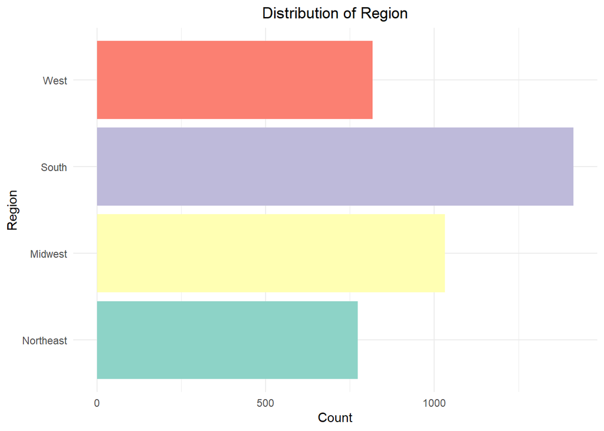

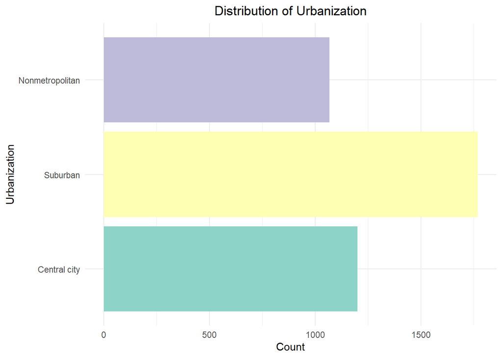

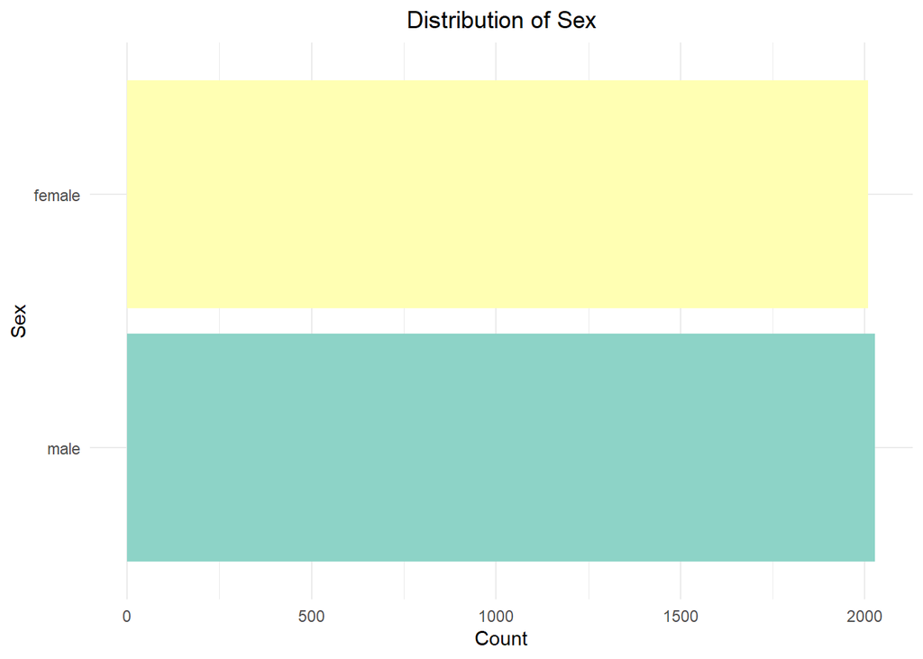

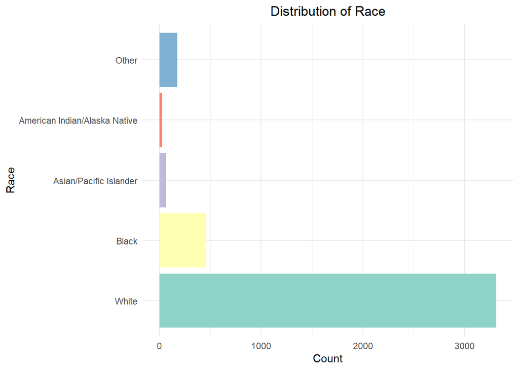

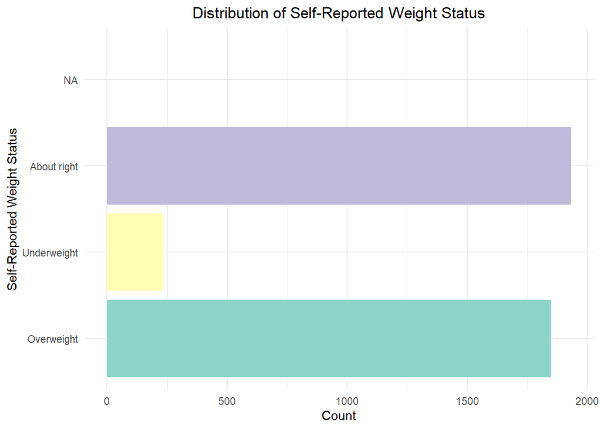

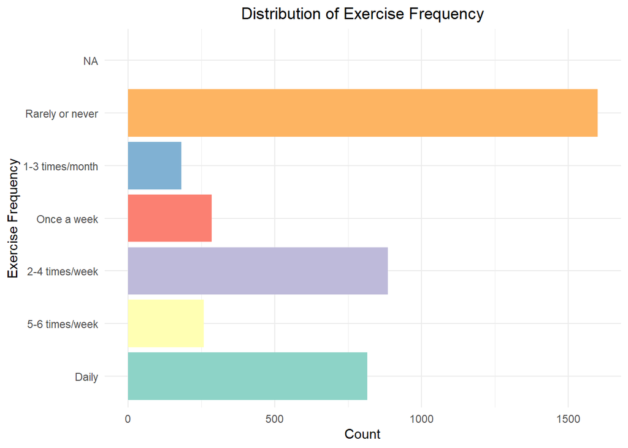

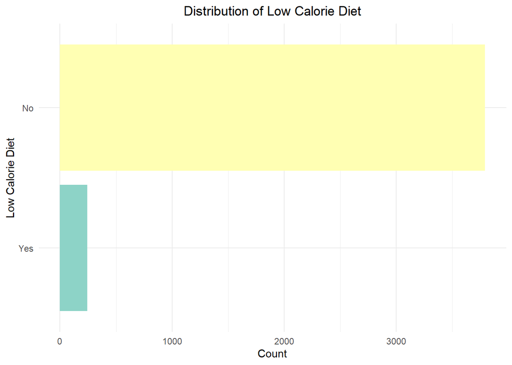

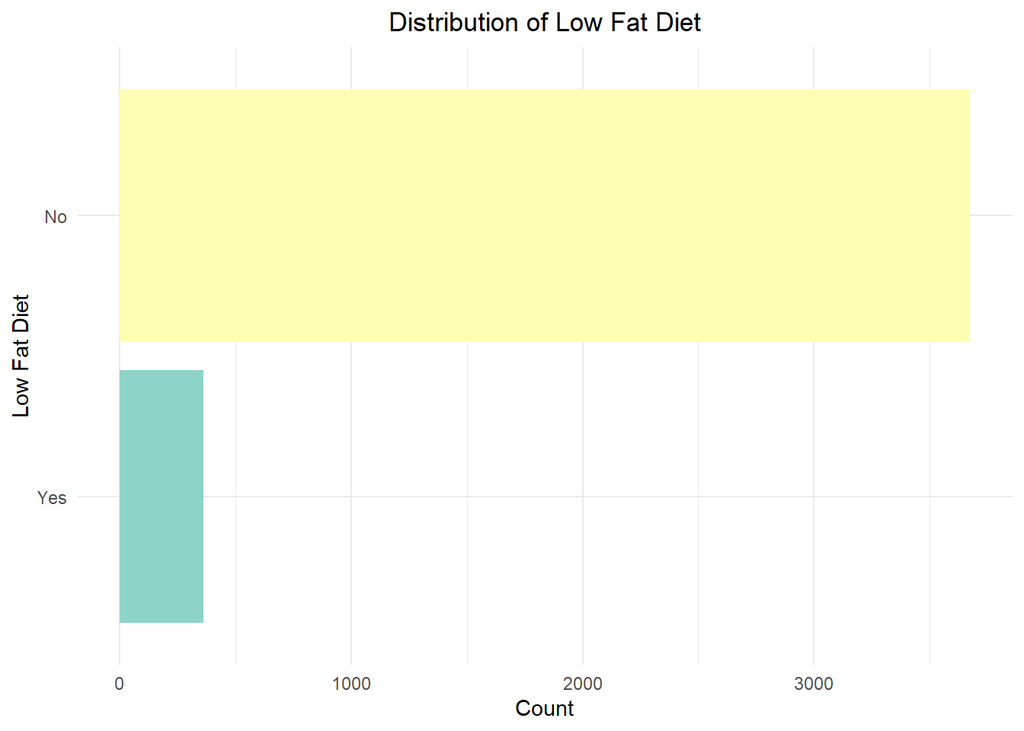

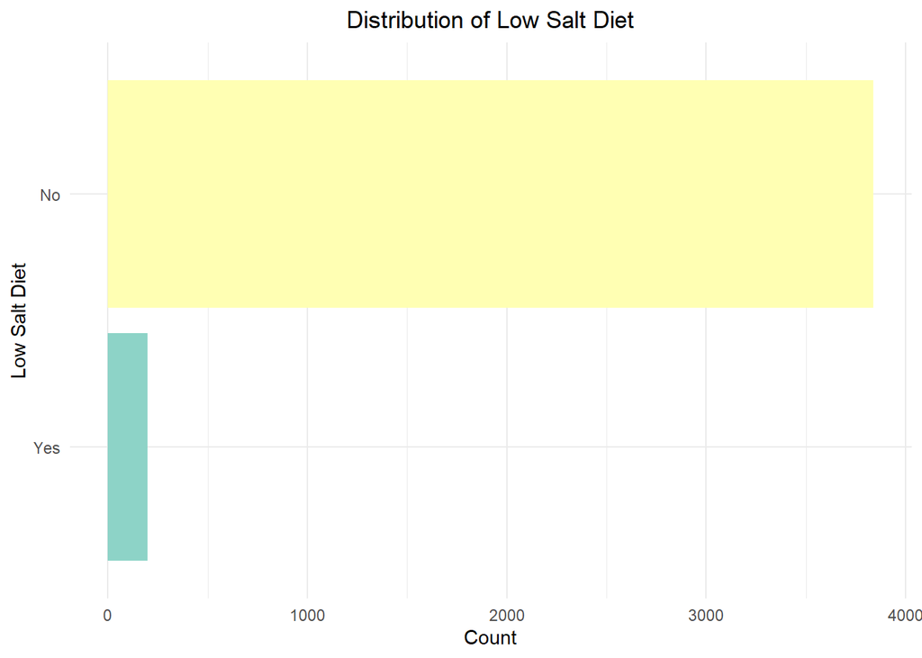

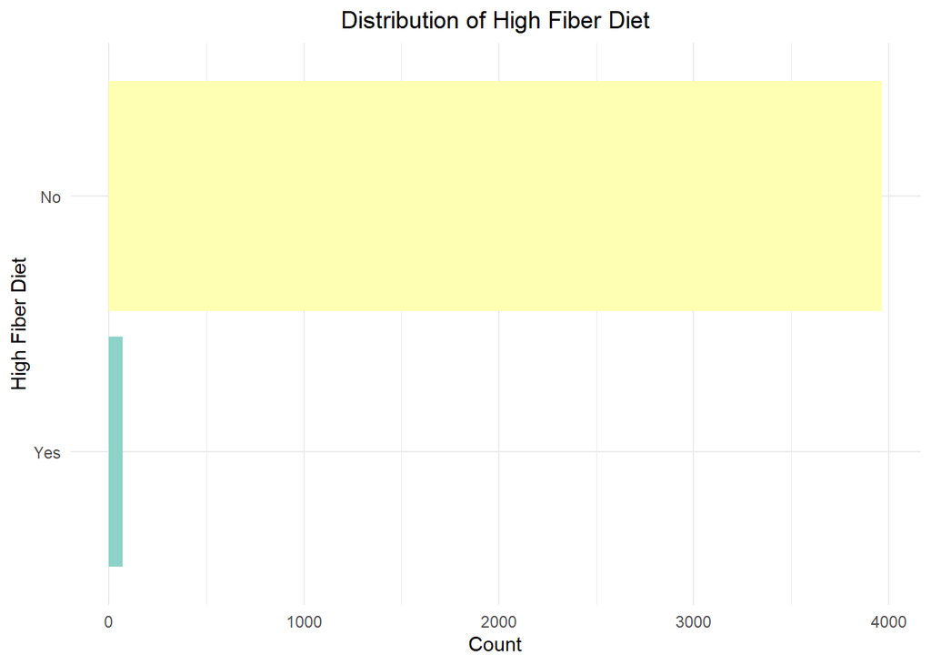

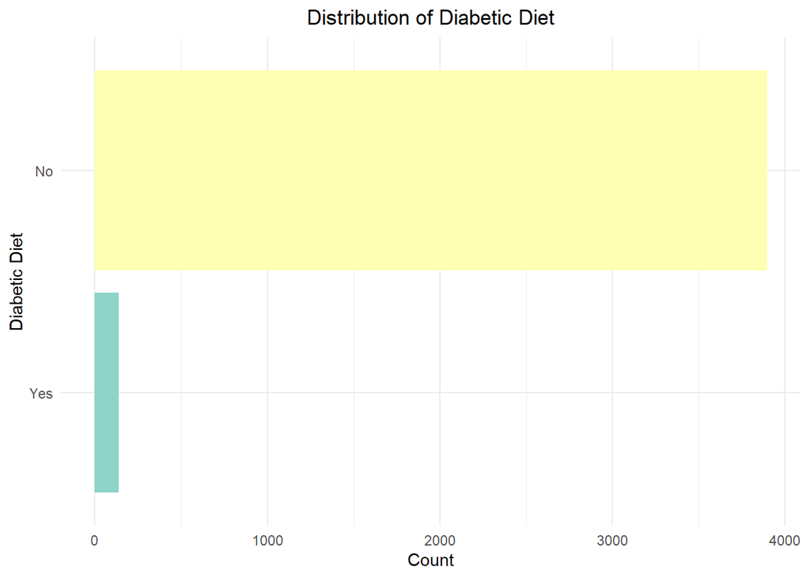

```r
# function to generate bar plots
create_bar_plot <- function(data, var_name, title) {
  ggplot(data, aes_string(x = var_name, fill = var_name)) +
    geom_bar() +
    labs(title = paste("Distribution of", title),
         x = title,
         y = "Count") +
    scale_fill_brewer(palette = "Set3")+
    theme_minimal() +
     theme(
      legend.position = "none",
      plot.title = element_text(hjust = 0.5)
    )+
    coord_flip()

}

for (var in names(categorical_vars_info)) {

  # create plot
  plot <- create_bar_plot(df_nutrition, var, categorical_vars_info[[var]])

  # save plot
  filename <- file.path("Plots", paste0("bar_plot_", var, ".png"))
  ggsave(filename, plot, width = 8, height = 6, dpi = 300)

  print(plot)
}
```

Bar subplots plots for each categorical variables in one master plot to use in word

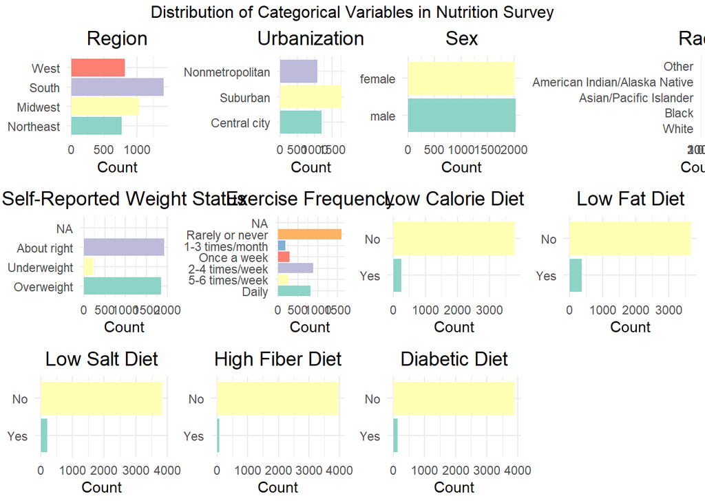

```r
library(gridExtra)
library(grid)

create_bar_plot <- function(data, var_name, title) {
  ggplot(data, aes_string(x = var_name, fill = var_name)) +
    geom_bar() +
    labs(title = title,
         x = NULL,
         y = "Count") +
    theme_minimal() +
    scale_fill_brewer(palette = "Set3") +
    theme(legend.position = "none",
          plot.title = element_text(hjust = 0.5, size = 14))+
    coord_flip()
}

# generate all plots
plot_list <- lapply(names(categorical_vars_info), function(var) {
  create_bar_plot(df_nutrition, var, categorical_vars_info[[var]])
})

# arrange and save the master plot
title <- "Distribution of Categorical Variables in Nutrition Survey"
combined_plot <- do.call(grid.arrange,
                        c(plot_list,
                          ncol = 4,
                          top = title))
```

```r
ggsave("Plots/categorical_distributions.png", combined_plot,
       width = 20, height = 10, dpi = 300)
```

### Preprocessing numeric variables

Although “grade” is an ordinal variable, I’ll treat it as a continuous variable due to the high number of levels.

```r
# function to calculate comprehensive descriptive statistics and return as a data frame
analyze_numeric_variables <- function(data, variables) {
  results <- list()

  for(variable_name in variables) {
    x <- data[[variable_name]]

    # basic stats
    stats <- data.frame(
      Variable = variable_name,
      n_obs = length(x),
      n_valid = sum(!is.na(x)),
      mean = mean(x, na.rm = TRUE),
      sd = sd(x, na.rm = TRUE),
      median = median(x, na.rm = TRUE),
      min = min(x, na.rm = TRUE),
      max = max(x, na.rm = TRUE),
      q1 = quantile(x, 0.25, na.rm = TRUE),
      q3 = quantile(x, 0.75, na.rm = TRUE),
      iqr = IQR(x, na.rm = TRUE),
      skewness = skewness(x, na.rm = TRUE),
      kurtosis = kurtosis(x, na.rm = TRUE)
    )

    # outlier statistics
    q1 <- quantile(x, 0.25, na.rm = TRUE)
    q3 <- quantile(x, 0.75, na.rm = TRUE)
    iqr <- IQR(x, na.rm = TRUE)
    lower_bound <- q1 - 1.5 * iqr
    upper_bound <- q3 + 1.5 * iqr
    outliers <- x[x < lower_bound | x > upper_bound]

    stats$n_outliers <- length(outliers)
    stats$pct_outliers <- length(outliers)/sum(!is.na(x))*100

    results[[variable_name]] <- stats
  }

  final_results <- do.call(rbind, results)
  row.names(final_results) <- NULL

  return(final_results)
}
```

```r
library(moments)

colSums(is.na(df_nutrition[numeric_vars]))
```

```
## income    age  grade
##      0      0      0
```

```r
# change values of 'grade' greater than 17 to NA
df_nutrition$grade[df_nutrition$grade > 17] <- NA

colSums(is.na(df_nutrition[numeric_vars]))
```

```
## income    age  grade
##      0      0     40
```

```r
# detailed descriptive statistics
numeric_analysis <- analyze_numeric_variables(df_nutrition, numeric_vars)

# round and print results
numeric_cols <- sapply(numeric_analysis, is.numeric)
numeric_analysis[numeric_cols] <- round(numeric_analysis[numeric_cols], 2)
print(numeric_analysis)
```

[output not shown]

```r
table(df_nutrition$grade)
```

```
##
##    0    1    2    3    4    5    6    7    8    9   10   11   12   13   14   15
##   10    3   12   22   27   36   73   70  157  127  151  178 1376  258  389  167
##   16   17
##  439  501
```

Notes: 40 missing values in the education variable.  
12 value is very common (high school level)  
It is weird that 0 is the minimum and that it occurs 10 times, but it it was not mentioned in the instructions that this is a missing data.

No missing values in the income variable  
Income is positively skewed and the median is significantly lower than the mean

No missing values in the age variable  
The age range looks ok with no abnormalities

```r
table(df_nutrition[[var]])
```

```
##
##  Yes   No
##  138 3898
```

### Visualising numeric variables

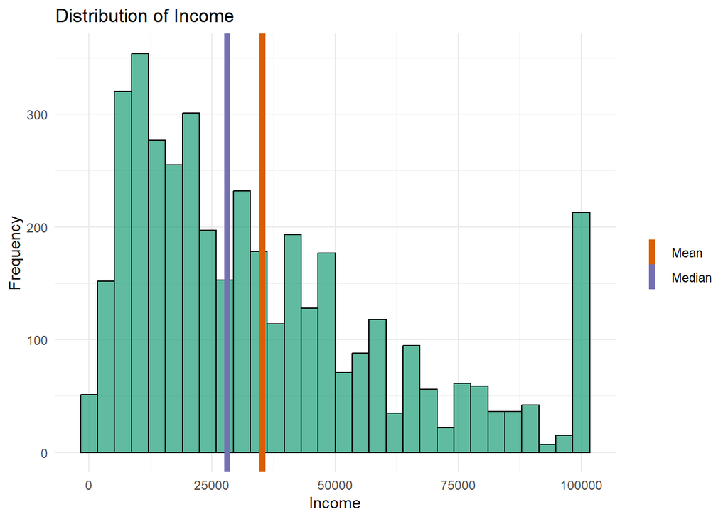

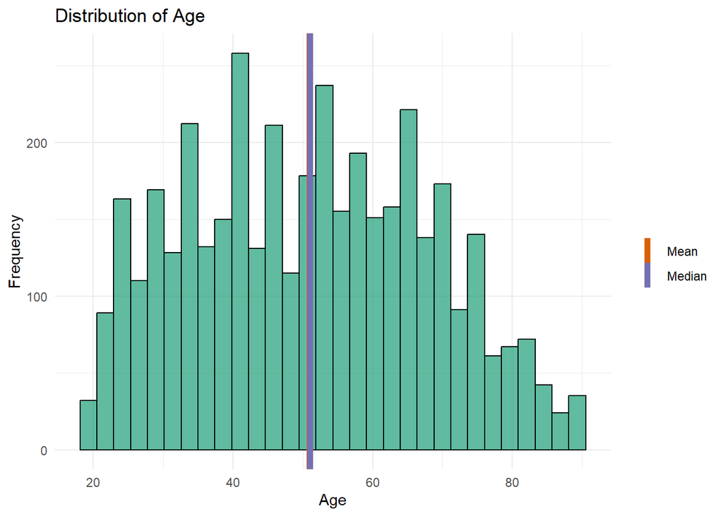

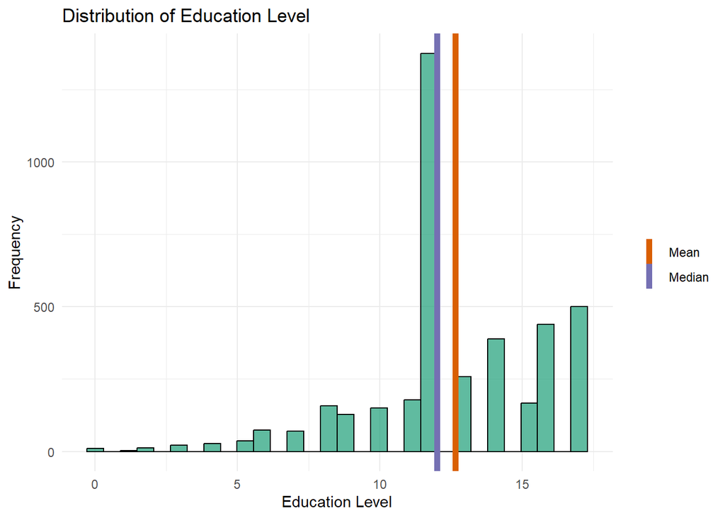

```r
# continuous variables
continuous_vars_info <- list(
  income = list(label = "Income"),
  age = list(label = "Age"),
  grade = list(label = "Education Level")
)

# function to plot histogram
create_histogram <- function(data, var_name, info) {

  mean_val <- mean(data[[var_name]], na.rm = TRUE)
  median_val <- median(data[[var_name]], na.rm = TRUE)

  ggplot(data, aes_string(x = var_name)) +
    geom_histogram(alpha = 0.7, color = "black", fill = "#1b9e77"
    ) +
    geom_vline(aes(xintercept = mean_val, color = "Mean"), linewidth = 2) +
    geom_vline(aes(xintercept = median_val, color = "Median"), linewidth = 2) +
    scale_color_manual(name = "", values = c("Mean" = "#d95f02", "Median" = "#7570b3")) +
    labs(
      title = paste("Distribution of", info$label),
      x = info$label,
      y = "Frequency"
    ) +
    theme_minimal()
}

# loop through variables to create and save plots
for (var in names(continuous_vars_info)) {

  plot <- create_histogram(df_nutrition, var, continuous_vars_info[[var]])

  filename <- file.path("Plots", paste0("histogram_", var, "_distribution.png"))
  ggsave(filename, plot, width = 10, height = 5, dpi = 300)

  print(plot)
}
```

### Correlations between variables

```r
# categorical variables
categorical_vars <- c("region", "urb", "sex", "race", "self_rep_weight",
                      "diet_low_cal", "diet_low_fat", "diet_low_salt",
                      "diet_high_fiber", "diet_diabetic", "exercise")
# numeric variables
numeric_vars <- c("income", "age", "grade")
```

#### Visualize correlations between numeric variables

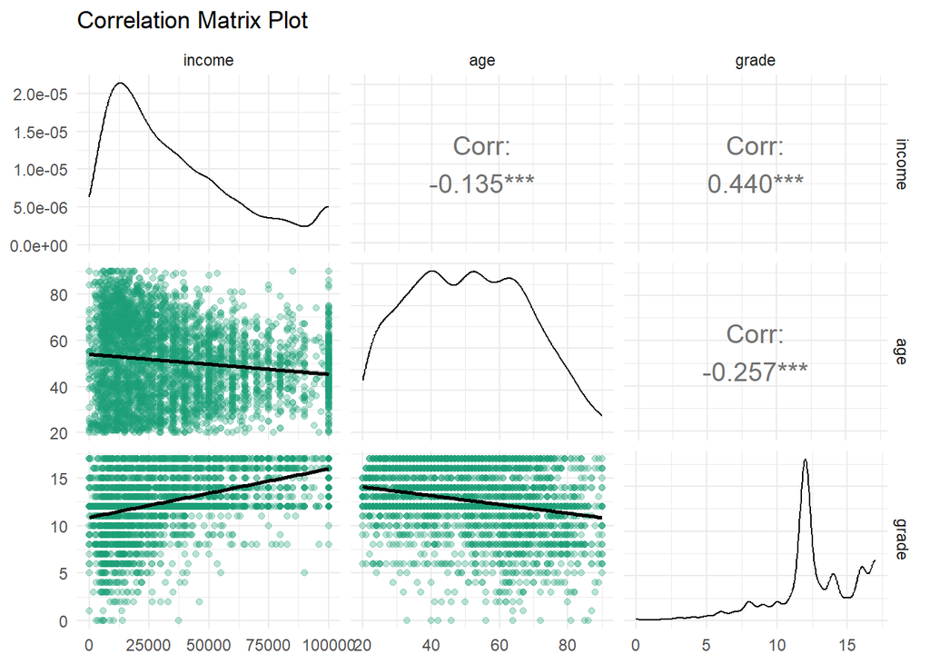

```r
# correlation plot matrix using GGally
library(GGally)
pairs_plot <- ggpairs(df_nutrition[numeric_vars],
        lower = list(continuous = wrap("smooth", alpha = 0.3, color = "#1B9E77")),
        upper = list(continuous = wrap("cor", size = 5))) +
  theme_minimal() +
  labs(title = "Correlation Matrix Plot")
pairs_plot
```

```r
ggsave("Plots/pairs_plot.png", pairs_plot, width = 6, height = 5, dpi = 300)
```

#### Visualize correlations between numeric variables and catagorical variables

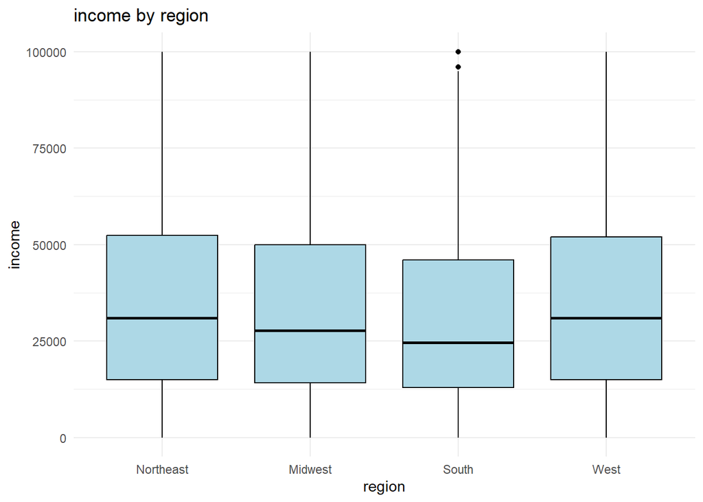

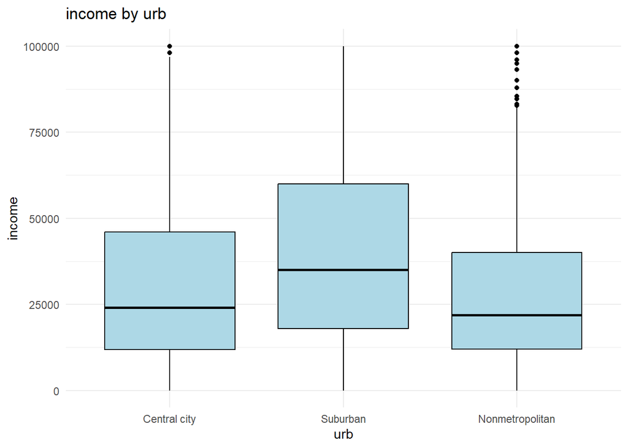

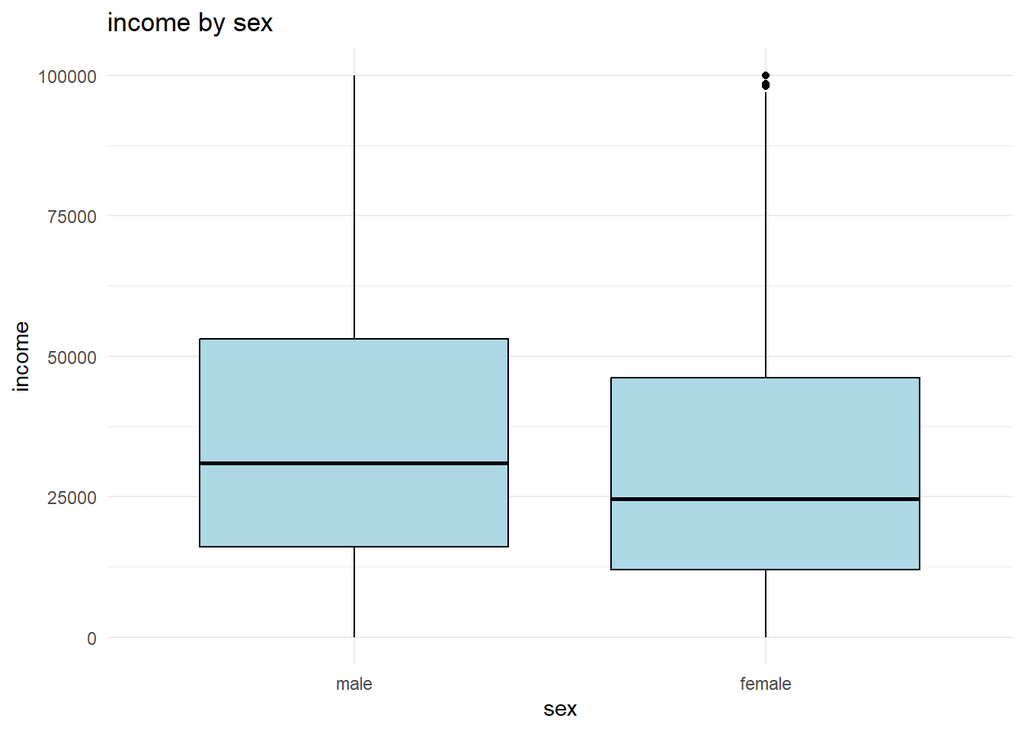

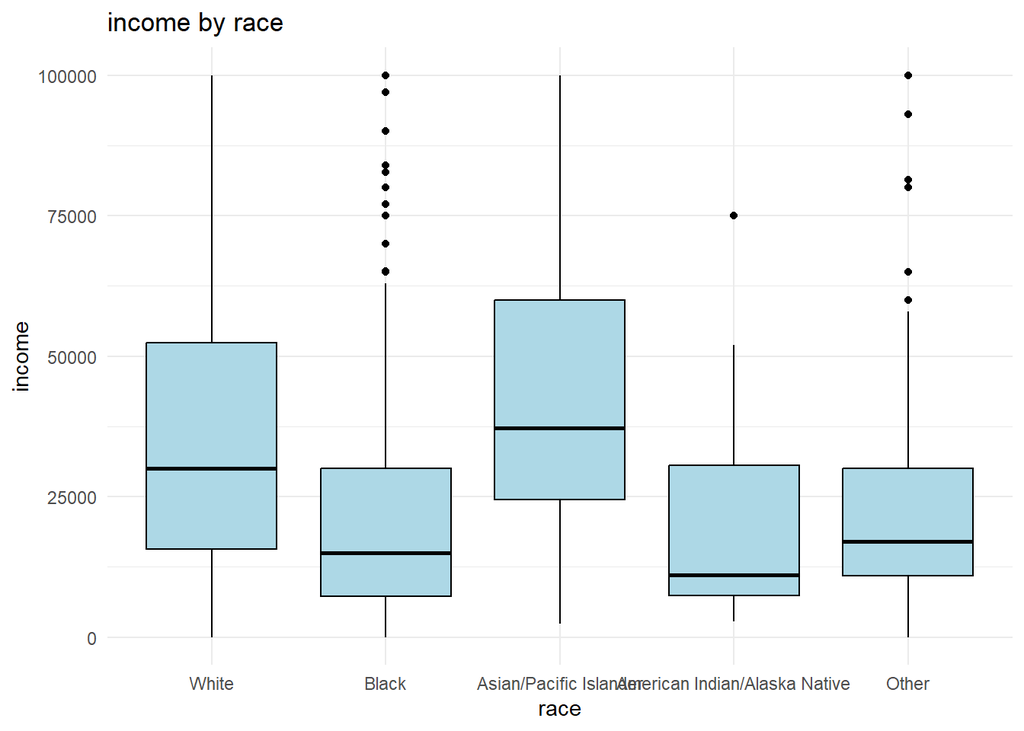

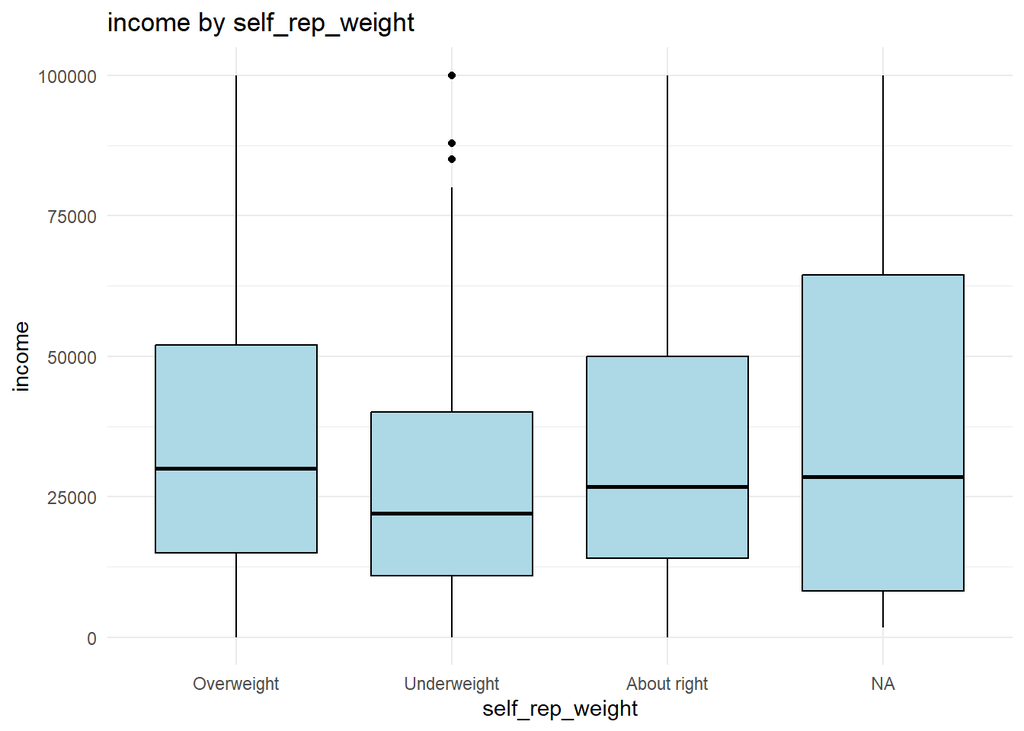

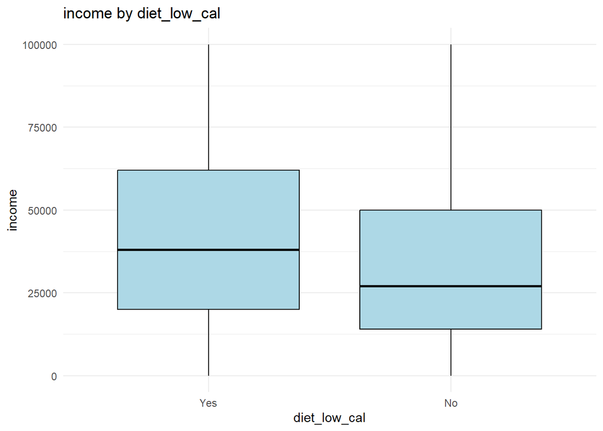

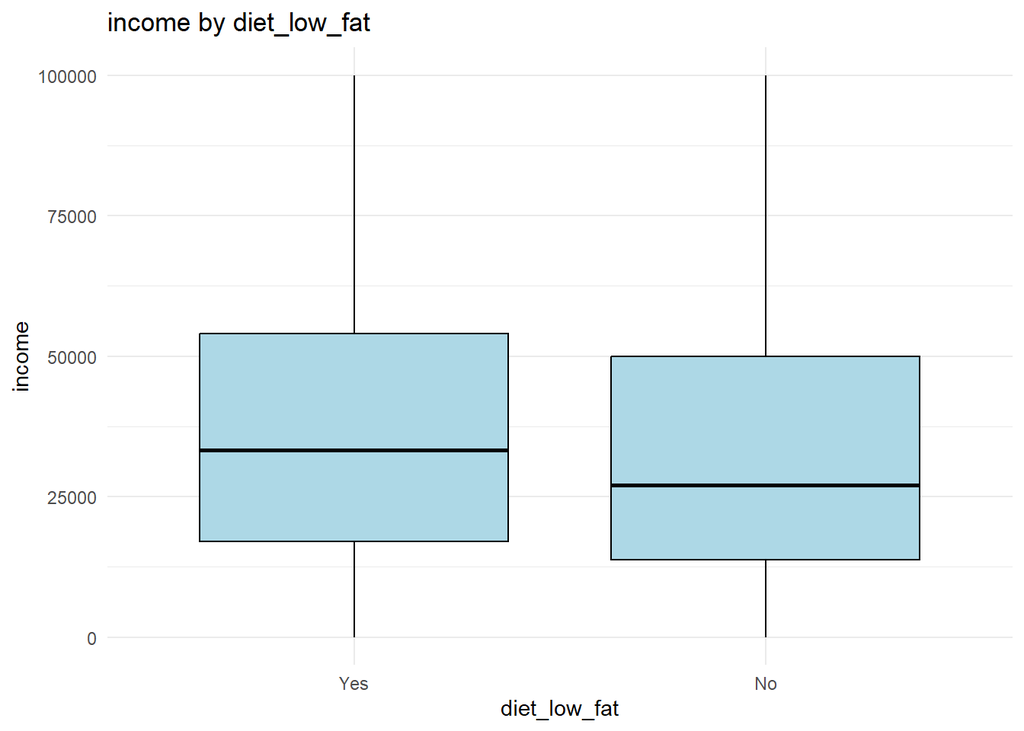

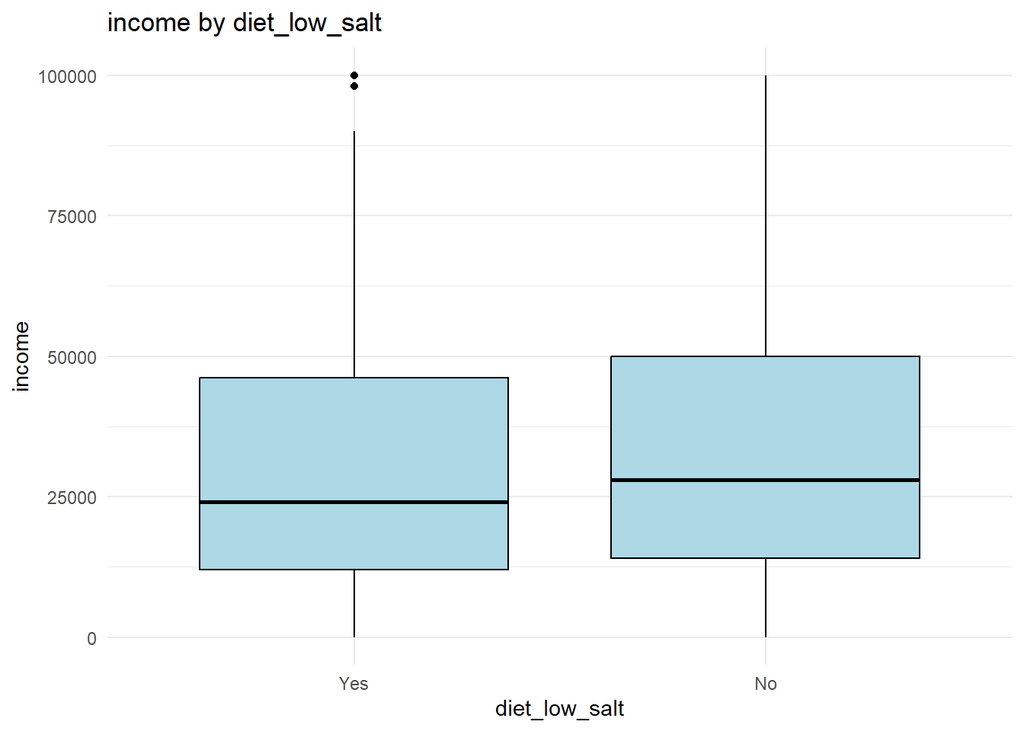

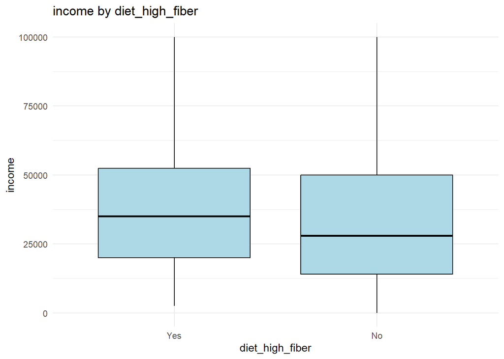

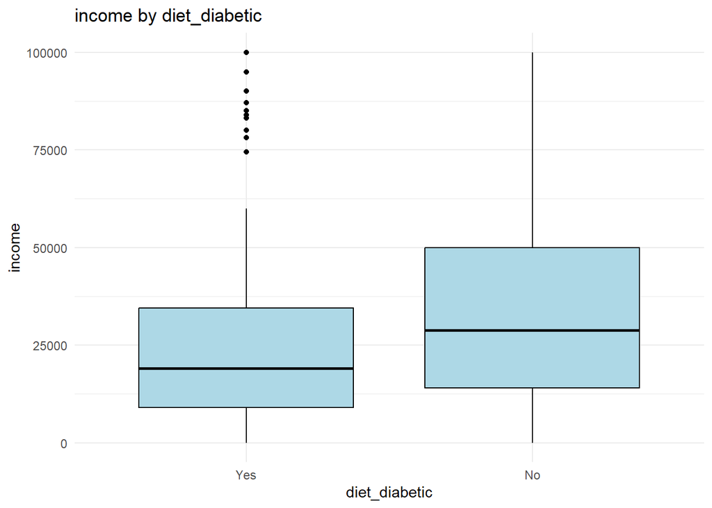

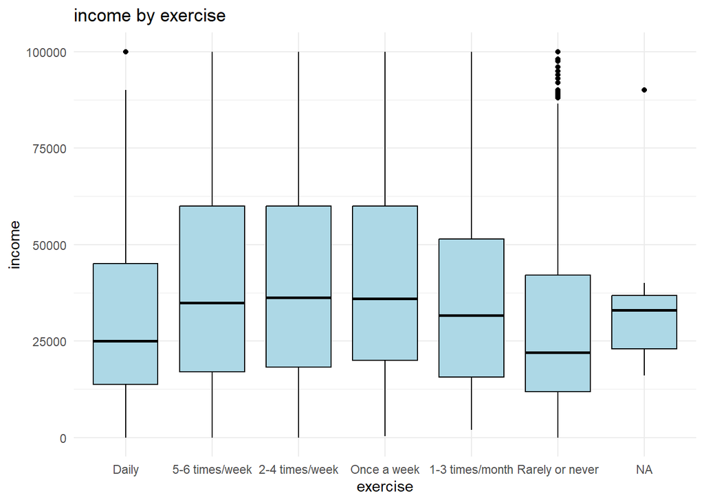

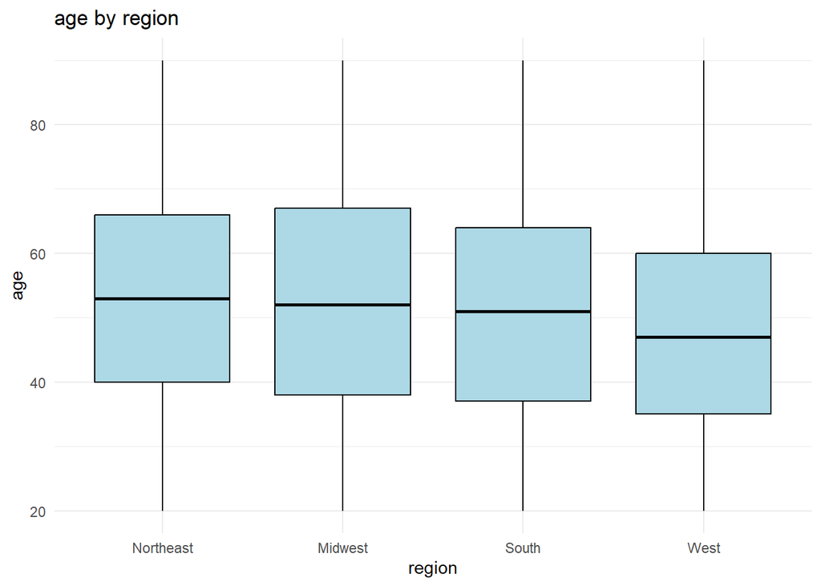

[21 more figures not shown]

```r
for (num_var in numeric_vars) {
  for (cat_var in categorical_vars) {

    # create boxplot for each combination of numeric and categorical variable
    p <- ggplot(df_nutrition, aes_string(x = cat_var, y = num_var)) +
      geom_boxplot(fill = "lightblue", color = "black") +
      labs(title = paste(num_var, "by", cat_var),
           x = cat_var, y = num_var) +
      theme_minimal()
      print(p)
  }
}
```

The initial plots show relationships between all categorical and numeric variables,  
but this makes it difficult to identify meaningful associations.  
To focus on the most important relationships, I willl only plot relationships where:  
1. ANOVA tests show statistical significance (p < 0.05)  
2. Effect size (η²) is at least moderate (≥ 0.06)

```r
format_pvalue <- function(p) {
  if (p < 0.05) return("p < 0.05")
  return(sprintf("p = %.3f", p))
}

# function to calculate mean differences between groups
calculate_group_differences <- function(data, numeric_var, categorical_var) {
  # ANOVA
  model <- aov(as.formula(paste(numeric_var, "~", categorical_var)), data = data)
  p_value <- summary(model)[[1]]["Pr(>F)"][[1]][1]

  # eta squared (effect size)
  aov_table <- summary(model)[[1]]
  eta_squared <- aov_table$`Sum Sq`[1] / sum(aov_table$`Sum Sq`)

  return(list(p_value = p_value, eta_squared = eta_squared))
}

# store results to sort by effect size
plot_results <- list()

# create plots and store results
for (num_var in numeric_vars) {
  for (cat_var in categorical_vars) {
    # calc statistics
    stats <- calculate_group_differences(df_nutrition, num_var, cat_var)

    # check if there's statistical significance and medium effect size
    if (stats$p_value < 0.05 && stats$eta_squared >= 0.06) {

      # annotation text
      stat_text <- sprintf(
        "ANOVA: %s\nEffect size (η²) = %.3f",
        format_pvalue(stats$p_value),
        stats$eta_squared
      )

      # boxplot
      p <- ggplot(df_nutrition, aes_string(x = cat_var, y = num_var)) +
        geom_violin(fill = "lightgray", alpha = 0.3) +
        geom_boxplot(fill = "#1B9E77", alpha = 0.7, width = 0.5, outlier.shape = NA) +
        geom_jitter(width = 0.2, alpha = 0.1, color = "black", size = 0.5) +
        annotate("text", x = Inf, y = Inf, label = stat_text,
                 hjust = 1.1, vjust = 1.1, size = 3) +
        theme_minimal() +
        theme(
          axis.text.x = element_text(angle = 45, hjust = 1),
          plot.title = element_text(hjust = 0.5, size = 12, face = "bold"),
          plot.subtitle = element_text(hjust = 0.5, size = 10),
          panel.grid.minor = element_blank(),
          plot.margin = margin(0.5, 0.5, 0.5, 0.5, "cm")
        ) +
        labs(
          title = paste(num_var, "by", cat_var),
          x = str_to_title(cat_var),
          y = str_to_title(num_var)
        )

      # store plot with its effect size for sorting
      plot_results[[length(plot_results) + 1]] <- list(
        plot = p,
        eta_squared = stats$eta_squared,
        p_value = stats$p_value,
        variables = paste(num_var, "by", cat_var)
      )
    }
  }
}

# sort results by effect size
plot_results <- plot_results[order(sapply(plot_results, function(x) -x$eta_squared))]

# Print summary of findings
cat("\nSignificant relationships with medium/large effect size (η² ≥ 0.06):\n")
```

```
##
## Significant relationships with medium/large effect size (η² ≥ 0.06):
```

```r
for(result in plot_results) {
  cat(sprintf("%s: η² = %.3f, %s\n",
              result$variables,
              result$eta_squared,
              format_pvalue(result$p_value)))
}
```

```
## grade by exercise: η² = 0.063, p < 0.05
## age by exercise: η² = 0.063, p < 0.05
```

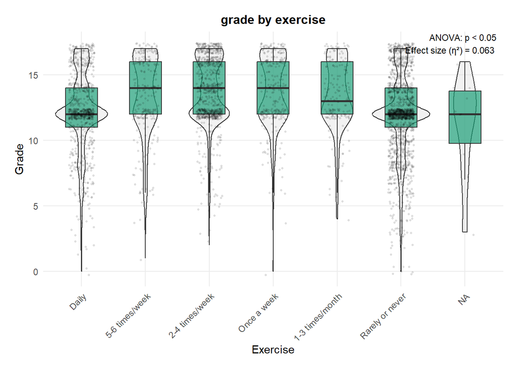

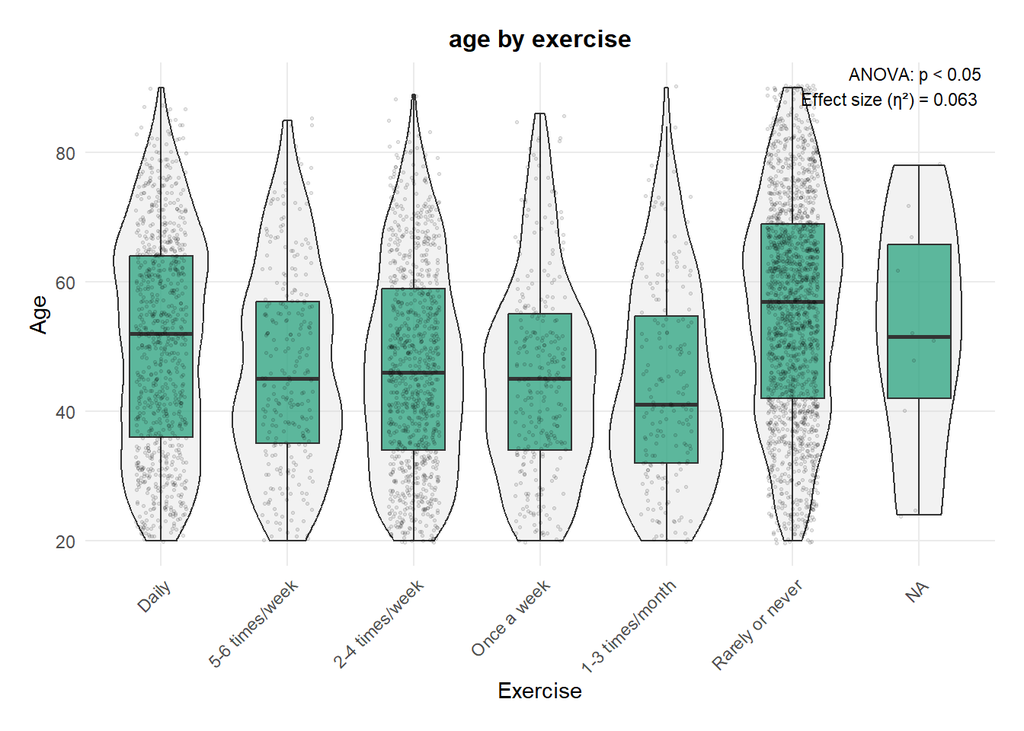

```r
# print plots in order of effect size and save them
for(result in plot_results) {
  print(result$plot)
  ggsave(paste0("Plots/cat_num", result$variables,".png"),
         result$plot, width = 10, height = 5, dpi = 300)
}
```